# index

### **Vitor Borges Jr**

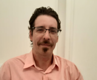

Sou biólogo de formação, especializado em ecologia de populações e comunidades e fascinado por análise de dados. A ecologia se transforma velozmente em uma ciência cada vez mais numérica e preditiva. Esta transformação me levou ao aprofundamento na área de ecologia numérica e da biologia computacional. Tenho conhecimento avançado no uso da linguagem R de programação, análises exploratórias de dados, tanto gráficas quanto estatísticas, delineamento experimental, teste de hipóteses, modelos determinísticos, estocásticos e análises multivariadas (ex. redução de dimensionalidade) e continuo buscando o aprendizado de novas ferramentas. Tenho experiência em inventário e monitoramento de vertebrados terrestres, resgate de fauna, ensino e pesquisa nas áreas de delineamento de estudos e análise de dados ecológicos, ecologia de populações e comunidades e ecologia da paisagem. Atualmente, busco aprimorar minha capacidade analítica e computacional avançando sobre o aprendizado e aplicação da linguagem Python de programação, suas ferramentas para manipulação, exploração, visualização, análise e modelagem de dados, técnicas de machine learning, assim como o servidor SQL para manipulação de banco de dados relacionais. Após cerca de 20 anos atuando no ensino e pesquisa na área de ecologia, optei pelo desafio de redirecionar minha atuação profissional à ciência de dados.

[LinkedIn](https://www.linkedin.com/in/vitor-borges-1bb19aa4/)

[Lattes](http://lattes.cnpq.br/2313576480433850)

[GitHub](https://github.com/vntborgesjr)

E-mail: vntborgesjr@gmail.com

### Visite os links abaixo!!!

### [Blog AnalisaR](https://vntborgesjr.github.io/AnalisaR/)

### [Postagens AnalisaR](https://vntborgesjr.github.io/AnalisaR/Posts.html)

### [Cursos AnalisaR](https://vntborgesjr.github.io/AnalisaR/Cursos.html)